# (140.644) Tutorial 3 Part 2: Assignment 2 Code

# Assignment 2 Code

The following questions are based on the non-experimental data to examine whether non-cigarette smoking adolescents who smoke marijuana have higher odds of smoking as adults than those who do not smoke marijuana during adolescence. The data comes from the **Add Health** study (http://www.cpc.unc.edu/projects/addhealth)

The original data contains information on 1541 individuals, 119 who smoke marijuana during adolescence and 1422 who did not. All covariates are measured at baseline.

The variables (1 treatment, 1 outcome, 8 covariates) in our data set are:

- **exposure1**: Indicator for whether or not marijuana was smoked in adolescence. 1=yes, 0=no
- **smoke1:** Indicator for whether individual smoked in adulthood. 1=yes, 0=no
- **age:** Age at study entry (continuous)
- **male:** Indicator for whether the individual was male. 1=yes, 0=no
- **white:** Indicator for whether the individual was White or not. 1=yes, 0=no
- **susp:** Indicator for whether the individual was ever suspended from school. 1=yes, 0=no
- **mathG:** Math grade (ordinal, 1-4 corresponding to A-D)
- **readG:** Reading grade (ordinal, 1-4 corresponding to A-D)
- **parentED:** Parent education (ordinal, 1-5 corresponding to less than high school, high school, vocational school, some college, and college graduate (and beyond)).
- **housesmoke:** Indicator for the presence of a cigarette smoker in the household. 1=yes, 0=no

## Read in the data

First download the data from the Online Library on Courseplus (*Datasets for Problem Sets>Problem Set 2* or also *Tutorial 3* folder).

```r
load(here("ADDHEALTH.Rdata"))
```

Alternative ways to load data:

```r
#Set working directory to your own folder where the data is
#Can also use Session > Set Working Directory > Choose Directory...
#setwd("/Users/graceringlein/Library/CloudStorage/OneDrive-JohnsHopkins/courses/causal_TA/causal_140.664_tutorials")
#getwd()
```

`ADDHEALTH.Rdata` contains an object called ‘df’ that is now loaded into the environment.

Here are some commands to take a look at the data structure:

```r
names(df)
```

```
##  [1] "exposure1"  "male"       "white"      "age"        "susp"
##  [6] "mathG"      "readG"      "parentED"   "housesmoke" "smoke1"
```

```r
head(df)
```

```
##   exposure1 male white age susp mathG readG parentED housesmoke smoke1
## 1         0    1     0  16    1     3     3        4          1      0
## 2         0    0     1  16    0     3     3        5          0      0
## 3         0    0     1  16    0     2     1        5          0      0
## 4         0    1     1  16    0     4     2        1          1      0
## 5         0    1     0  17    1     3     4        2          1      1
## 6         0    1     1  18    1     3     1        2          1      0
```

```r
summary(df)
```

```
##    exposure1            male        white        age        susp     mathG
##  Min.   :0.00000   Min.   :0.0000   0:563   Min.   :16.00   0:1177   1:419
##  1st Qu.:0.00000   1st Qu.:0.0000   1:978   1st Qu.:16.00   1: 364   2:517
##  Median :0.00000   Median :0.0000           Median :17.00            3:390
##  Mean   :0.07722   Mean   :0.4802           Mean   :16.88            4:215
##  3rd Qu.:0.00000   3rd Qu.:1.0000           3rd Qu.:18.00
##  Max.   :1.00000   Max.   :1.0000           Max.   :18.00
##  readG   parentED housesmoke     smoke1
##  1:501   1:190    0:945      Min.   :0.0000
##  2:605   2:455    1:596      1st Qu.:0.0000
##  3:321   3:169               Median :0.0000
##  4:114   4:287               Mean   :0.3134
##          5:440               3rd Qu.:1.0000
##                              Max.   :1.0000
```

```r
dim(df)
```

```
## [1] 1541   10
```

```r
table(df$exposure1)
```

```
##
##    0    1
## 1422  119
```

## PS Weighting using WeightIt

`WeightIt` offers many different options for estimating weights. More info on `WeightIt` here: https://ngreifer.github.io/WeightIt/. We will estimate propensity scores using logistic regression and generalized boosted modeling (GBM). For the latter, we also need to install the `gbm` package. If you have not installed these packages, uncomment the following lines to install.

```r
#install.packages("WeightIt")
#install.packages("gbm")
```

```r
library(WeightIt)

ps.form <- exposure1~male+white+age+susp+mathG+readG+parentED+housesmoke

#Estimating weights from logistic regression PS
logreg.ATT <- weightit(ps.form, data = df, method = "ps", estimand = "ATT")

#Estimating weights using GBM PS
gbm.ATT <- weightit(ps.form, data = df, method = "gbm", estimand = "ATT",
                    stop.method = "ks.mean")
```

Extra code (not in problem set) to illustrate the structure of the weightit object, etc.

```r
logreg.ATT
```

```
## A weightit object
##  - method: "glm" (propensity score weighting with GLM)
##  - number of obs.: 1541
##  - sampling weights: none
##  - treatment: 2-category
##  - estimand: ATT (focal: 1)
##  - covariates: male, white, age, susp, mathG, readG, parentED, housesmoke
```

```r
names(logreg.ATT)
```

```
##  [1] "weights"   "treat"     "covs"      "estimand"  "method"    "ps"
##  [7] "s.weights" "focal"     "call"      "formula"   "env"
```

```r
summary(logreg.ATT)
```

```
##                   Summary of weights
##
## - Weight ranges:
##
##            Min                                    Max
## treated 1.0000                              || 1.0000
## control 0.0078   |----------------|            0.6032
##
## - Units with the 5 most extreme weights by group:
##
##             107     45     36     34     12
##  treated      1      1      1      1      1
##            1305    903    460    729    972
##  control 0.5283 0.5317 0.5317 0.5769 0.6032
##
## - Weight statistics:
##
##         Coef of Var   MAD Entropy # Zeros
## treated       0.000 0.000   0.000       0
## control       0.883 0.595   0.288       0
##
## - Effective Sample Sizes:
##
##            Control Treated
## Unweighted 1422.       119
## Weighted    798.91     119
```

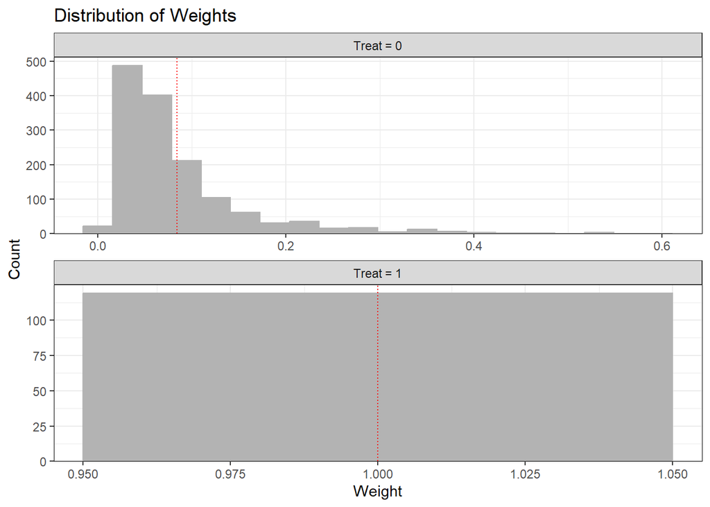

```r
plot(summary(logreg.ATT))
```

```r
#Demonstration that ATT weights are correctly computed from PS: weighting by the odds
logreg.ATT$weights[1:10]
```

```
##  [1] 0.24945336 0.08665186 0.03190119 0.03296791 0.33351379 0.13080929
##  [7] 0.03386588 0.09671463 0.06211379 0.03487686
```

```r
logreg.ATT$ps[1:10]
```

```
##  [1] 0.19965000 0.07974206 0.03091497 0.03191572 0.25010150 0.11567759
##  [7] 0.03275655 0.08818578 0.05848130 0.03370146
```

```r
logreg.ATT$ps[1:10] / (1-logreg.ATT$ps[1:10])
```

```
##  [1] 0.24945336 0.08665186 0.03190119 0.03296791 0.33351379 0.13080929
##  [7] 0.03386588 0.09671463 0.06211379 0.03487686
```

```r
logreg.ATT$weights[1:10]
```

```
##  [1] 0.24945336 0.08665186 0.03190119 0.03296791 0.33351379 0.13080929
##  [7] 0.03386588 0.09671463 0.06211379 0.03487686
```

```r
#One weight and PS per unit
dim(df)
```

```
## [1] 1541   10
```

```r
length(logreg.ATT$ps)
```

```
## [1] 1541
```

```r
length(logreg.ATT$weights)
```

```
## [1] 1541
```

## Assessing balance with cobalt (Covariate Balance Tables)

To examine the resulting balance from both of these methods, we will use the `cobalt` package. More info on `cobalt` here: https://ngreifer.github.io/cobalt/.

```r
#install.packages('cobalt')
```

```r
library(cobalt)
bal.tab(logreg.ATT) # bal.tab = balance table
```

```
## Balance Measures
##                Type Diff.Adj
## prop.score Distance  -0.0471
## male         Binary  -0.0014
## white        Binary   0.0016
## age         Contin.   0.0063
## susp         Binary  -0.0053
## mathG_1      Binary   0.0020
## mathG_2      Binary   0.0106
## mathG_3      Binary  -0.0025
## mathG_4      Binary  -0.0100
## readG_1      Binary  -0.0001
## readG_2      Binary   0.0046
## readG_3      Binary  -0.0012
## readG_4      Binary  -0.0033
## parentED_1   Binary  -0.0001
## parentED_2   Binary  -0.0013
## parentED_3   Binary   0.0042
## parentED_4   Binary  -0.0056
## parentED_5   Binary   0.0028
## housesmoke   Binary  -0.0041
##
## Effective sample sizes
##            Control Treated
## Unadjusted 1422.       119
## Adjusted    798.91     119
```

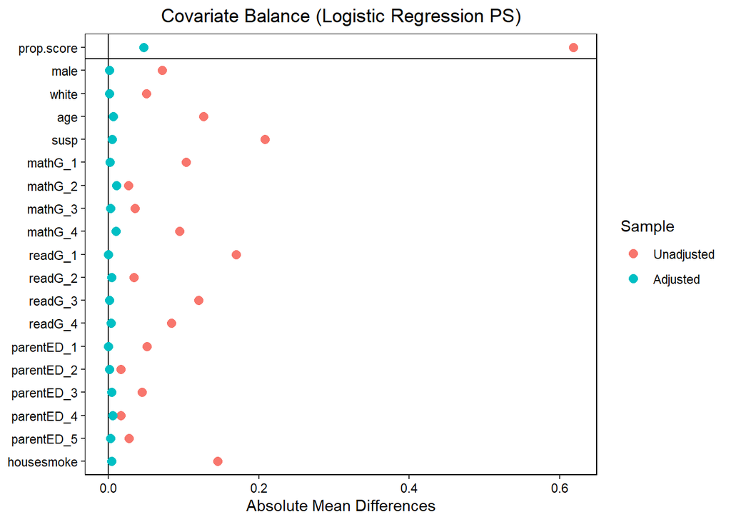

```r
love.plot(logreg.ATT, title="Covariate Balance (Logistic Regression PS)", abs = TRUE)
```

```r
bal.tab(gbm.ATT)
```

```
## Balance Measures
##                Type Diff.Adj
## prop.score Distance   0.4004
## male         Binary   0.0017
## white        Binary   0.0008
## age         Contin.  -0.0014
## susp         Binary   0.0185
## mathG_1      Binary  -0.0006
## mathG_2      Binary   0.0117
## mathG_3      Binary  -0.0106
## mathG_4      Binary  -0.0004
## readG_1      Binary  -0.0065
## readG_2      Binary  -0.0119
## readG_3      Binary   0.0100
## readG_4      Binary   0.0084
## parentED_1   Binary  -0.0029
## parentED_2   Binary  -0.0084
## parentED_3   Binary   0.0134
## parentED_4   Binary  -0.0060
## parentED_5   Binary   0.0039
## housesmoke   Binary   0.0083
##
## Effective sample sizes
##            Control Treated
## Unadjusted 1422.       119
## Adjusted    654.62     119
```

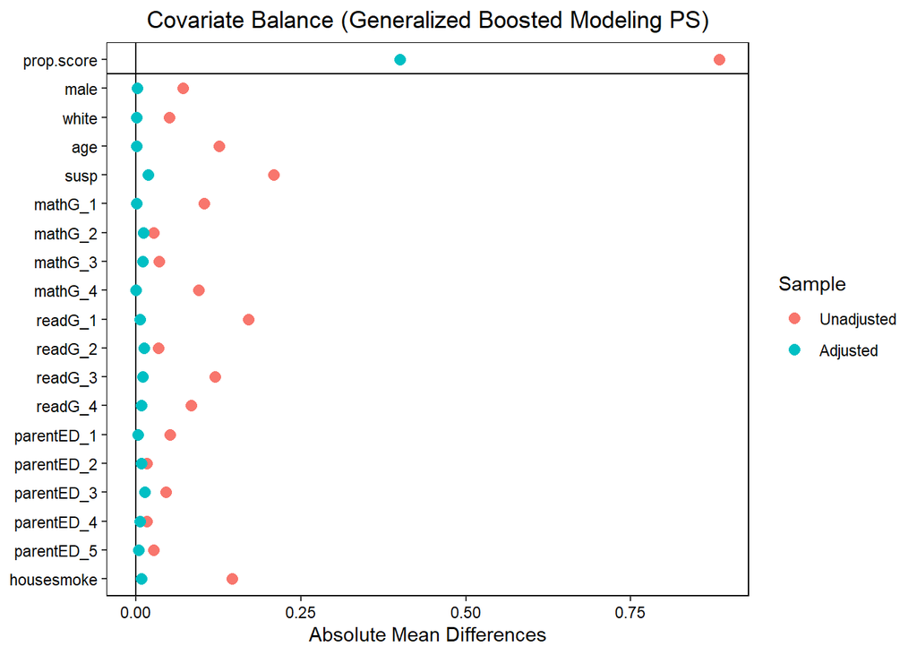

```r
love.plot(gbm.ATT, title="Covariate Balance (Generalized Boosted Modeling PS)", abs = TRUE)
```

## Estimate the treatment effect and its standard error using the GBM ATT weights

```r
#install.packages("sandwich")
#install.packages("lmtest")
```

```r
library(sandwich)
library(lmtest)
glm.gbmweight <- glm(smoke1 ~ exposure1, data = df, family = quasibinomial(),
                     weights = gbm.ATT$weights)
gbm.est <- coeftest(glm.gbmweight, vcov. = vcovHC)

gbm.est
```

```
##
## z test of coefficients:
##
##              Estimate Std. Error z value  Pr(>|z|)
## (Intercept) -0.679878   0.085359 -7.9650 1.653e-15 ***
## exposure1    0.730309   0.203699  3.5852 0.0003368 ***
## ---
## Signif. codes:  0 '***' 0.001 '**' 0.01 '*' 0.05 '.' 0.1 ' ' 1
```

```r
exp(coef(gbm.est)["exposure1"]) #OR of exposure1
```

```
## exposure1
##  2.075722
```

```r
exp(confint(gbm.est)["exposure1",]) #95% CI for OR of exposure1
```

```
##    2.5 %   97.5 %
## 1.392451 3.094270
```

## Unadjusted effect estimate

Run a logistic regression analysis to assess the unadjusted association between marijuana smoking in adolescence and smoking in adulthood.

```r
un.model <- glm(smoke1 ~ exposure1, data = df, family = quasibinomial())
un.est <- coeftest(un.model)

un.est
```

```
##
## z test of coefficients:
##
##              Estimate Std. Error z value  Pr(>|z|)
## (Intercept) -0.862750   0.058087 -14.853 < 2.2e-16 ***
## exposure1    0.913181   0.192491   4.744 2.095e-06 ***
## ---
## Signif. codes:  0 '***' 0.001 '**' 0.01 '*' 0.05 '.' 0.1 ' ' 1
```

```r
exp(coef(un.est)["exposure1"]) #OR of exposure1
```

```
## exposure1
##  2.492237
```

```r
exp(confint(un.est)["exposure1",]) #95% CI for OR of exposure1
```

```
##    2.5 %   97.5 %
## 1.708996 3.634441
```

### Note:

Q20 is conceptual and doesn’t require code, just interpretation of the plot provided in the quiz.

## Full matching using MatchIt (Q21)

`MatchIt` performs propensity score matching and other matching methods. More info on `MatchIt` here: https://kosukeimai.github.io/MatchIt.

```r
#install.packages("MatchIt")
#Note: you need to also install the optmatch package to use full matching
#install.packages("optmatch")
```

```r
library(MatchIt)
match1 <- matchit(ps.form, data=df, method="full", estimand="ATT")

bal.tab(match1)
```

```
## Balance Measures
##                Type Diff.Adj
## distance   Distance   0.0006
## male         Binary  -0.0254
## white        Binary  -0.0092
## age         Contin.   0.0723
## susp         Binary  -0.0421
## mathG_1      Binary   0.0071
## mathG_2      Binary  -0.0252
## mathG_3      Binary   0.0032
## mathG_4      Binary   0.0149
## readG_1      Binary   0.0005
## readG_2      Binary  -0.0063
## readG_3      Binary  -0.0033
## readG_4      Binary   0.0091
## parentED_1   Binary   0.0004
## parentED_2   Binary  -0.0016
## parentED_3   Binary   0.0088
## parentED_4   Binary   0.0039
## parentED_5   Binary  -0.0117
## housesmoke   Binary   0.0295
##
## Sample sizes
##                      Control Treated
## All                   1422.      119
## Matched (ESS)          393.6     119
## Matched (Unweighted)  1422.      119
```

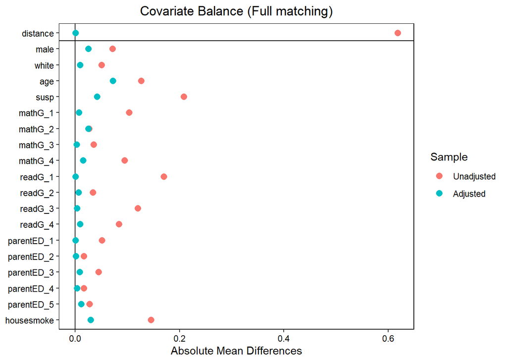

```r
love.plot(match1, title="Covariate Balance (Full matching)", abs = TRUE)
```

```r
matched1 <- match.data(match1)
fullmodel <- glm(smoke1 ~ exposure1, data = matched1, family = quasibinomial(),
                 weights = weights)
full.est <- coeftest(fullmodel, vcov. = vcovCL, cluster = ~subclass)

exp(coef(full.est)["exposure1"]) #OR of exposure1
```

```
## exposure1
##   2.28206
```

```r
exp(confint(full.est)["exposure1",]) #95% CI for OR of exposure1
```

```
##    2.5 %   97.5 %
## 1.548408 3.363326
```

## Comparing balance across methods

```r
bal.tab(ps.form, data = df, un = TRUE,
        weights = list(logreg = logreg.ATT,
                       gbm = gbm.ATT,
                       full = match1))
```

```
## Balance Measures
##               Type Diff.Un Diff.logreg Diff.gbm Diff.full
## male        Binary  0.0715     -0.0014   0.0017   -0.0254
## white       Binary -0.0503      0.0016   0.0008   -0.0092
## age        Contin.  0.1263      0.0063  -0.0014    0.0723
## susp        Binary  0.2085     -0.0053   0.0185   -0.0421
## mathG_1     Binary -0.1034      0.0020  -0.0006    0.0071
## mathG_2     Binary -0.0266      0.0106   0.0117   -0.0252
## mathG_3     Binary  0.0354     -0.0025  -0.0106    0.0032
## mathG_4     Binary  0.0947     -0.0100  -0.0004    0.0149
## readG_1     Binary -0.1702     -0.0001  -0.0065    0.0005
## readG_2     Binary -0.0339      0.0046  -0.0119   -0.0063
## readG_3     Binary  0.1203     -0.0012   0.0100   -0.0033
## readG_4     Binary  0.0837     -0.0033   0.0084    0.0091
## parentED_1  Binary -0.0517     -0.0001  -0.0029    0.0004
## parentED_2  Binary  0.0170     -0.0013  -0.0084   -0.0016
## parentED_3  Binary  0.0451      0.0042   0.0134    0.0088
## parentED_4  Binary  0.0167     -0.0056  -0.0060    0.0039
## parentED_5  Binary -0.0271      0.0028   0.0039   -0.0117
## housesmoke  Binary  0.1455     -0.0041   0.0083    0.0295
##
## Effective sample sizes
##        Control Treated
## All    1422.       119
## logreg  798.91     119
## gbm     654.62     119
## full    393.6      119
```

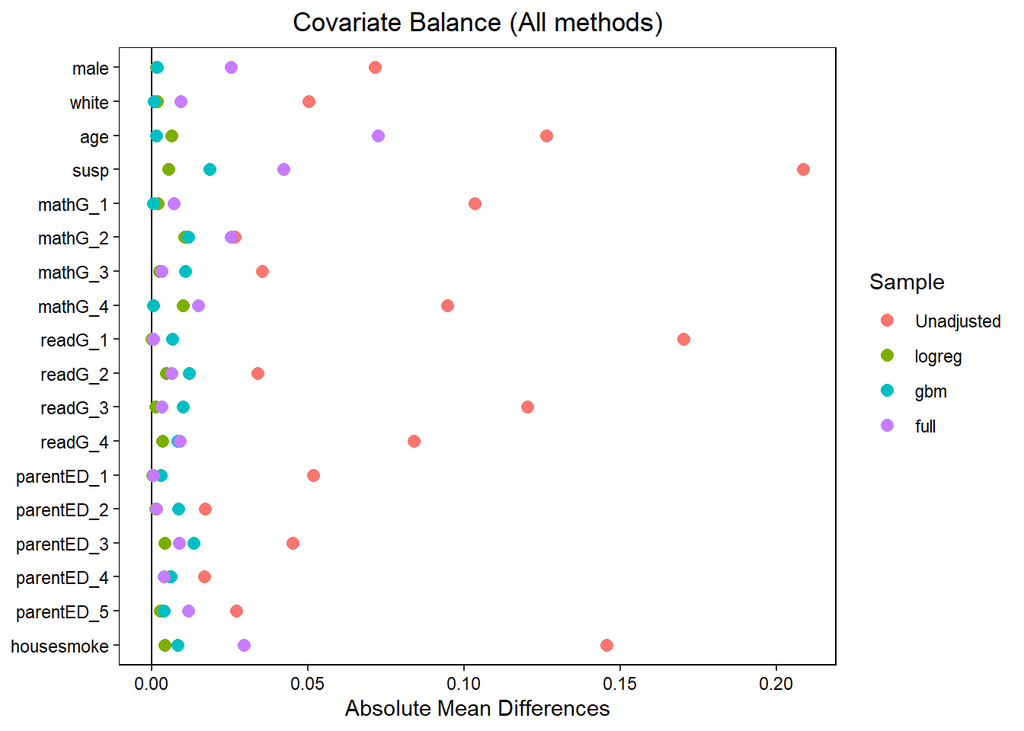

```r
love.plot(ps.form, data = df, abs = TRUE,
          title = "Covariate Balance (All methods)",
          weights = list(logreg = logreg.ATT,
                         gbm = gbm.ATT,
                         full = match1))
```

## Note about Q28:

*Using one of the three propensity-score approaches you just explored with the AddHealth data, in 1-2 paragraphs write a sample “Methods” section for a research paper where you discuss the use of propensity scores to estimate causal effects. Think through (and include) the aspects of the analysis that you think are important to convey, such as the estimand and the method used, as well as other important pieces of information. Focus on the propensity-score aspects of the methods; you do not need to discuss more general methods-related topics, such as the data and measures used. (Answer in 500 words or less)*

**Points of clarification:**

- Choose propensity score weighting (with logistic regression weights), propensity score weighting (with GBM weights) or full matching to discuss. It is not required to discuss multiple of these methods. If you really would like to discuss multiple, you can, but be concise.
- See “Extra slides: Good PS Methods Sections” and “Sample Propensity Score Writeups” *(*in the Online Library > Tutorial 3) for examples
  - *Some* important components:
    - Method used
    - Estimand of interest
    - If relevant, were any covariates treated in a special way (i.e. exact matching)
    - Some diagnostics of how balance is assessed
    - Describe how the effect is estimated